# Quantitative Genetics

GxE interaction – AMMI analyses

Felipe Ferrão

University of Florida

**Objectives:**

- 30 minutes of hands-on
- GxE interaction

**Extra information**

- [PCB 6555 – Website](https://lfelipe-ferrao.github.io/class/quantGenetic/)
- About the [author](https://lfelipe-ferrao.github.io/)
- About the [UF/IFAS Plant Breeding](https://programs.ifas.ufl.edu/plant-breeding/)

# Introduction

There are several alternatives to quantify GxE analyses. Previously, we reported it in the form of linear regression, and we interpreted the slope as metric of plasticity. In the AMMI (Additive Main effect Multiplicative Interaction) we will report it as an ANOVA analyses and use the outcomes to visualize the dataset and explore graphically its pattern and structure. The method received a particular attention from plant breeders, because of simplicity and easy interpretation.

# Theory

## AMMI models

The AMMI analysis combines the Analysis Of Variance (ANOVA) and the Singular Value Decomposition (SVD). Intuitivelly, the ANOVA partitions the total sum of squares into two main effects (genotypes and environments) plus the interaction effect (genotypes x environments). The interaction effect, is organized into a two-way matrix (genotypes on the rows, and environments on int he columns) and submitted to a SVD analyses. Thus, In the additive interaction in the ANOVA model is obtained by multiplication of genotype PC scores by environment PC scores, appropriately scaled. As indicated by its name, this class of models involves the product of a component due to genotypic term and a component due to the interaction.

We can write the model in the following way:

$$y_{ij} = \mu + G_i + E_j + \sum
b_{ik}z_{ik} + e_{ij}$$

where the GxE is explained by a multiplicative term, that is formed by the product between genotype and environment interaction.

Main objective of AMMI analyses is to obtain estimates of the performance of a genotype in a particular environment. To this end, a desirable property of the is that the genotypic and environmental scores can be used to construct powerful graphical representations called **biplots**.The use of such tools can help breeders to explain the GxE interaction, since genotype and environment can be ploted in the same graphical.

A central concept behind AMMI models is because the first few PCA axes tend to capture most of the interaction. Thus, environments are typically represented as axes intersecting at their origins.The origins represent the averages for the trait in the corresponding environments.

# Hands-on

## Data set

- Coffee data set
- 12 environments (combination of 3 locations and seasons)
- 27 genotypes (coffee cultivars) evaluated in RBD with 3 repetitions and 5 plants per plot
- Yield (bags per hectare) collected.
- [Link for the Ferrao et al., (2024) paper](https://acsess.onlinelibrary.wiley.com/doi/10.1002/csc2.21298)
- Goals:
  - Paper described the evaluation of *Coffea canephora* (Robusta coffee) under alternative environments – sites reported in the paper are located in high altitudes, that are not the best condictions for this type of coffee.
  - Objective 1: check the general performance and the plasticity of Robusta coffee
  - Objective 2: identify adaptable and stable genotypes

## R functions

In the sequence of this section, we will create the intuition behind the use of AMMI plots. Most of the ideas are presented by [Onofri and Ciriciofolo, 2007](https://journal.r-project.org/articles/RN-2007-003/RN-2007-003.pdf).

First, we will organize the coffee data set into a two-way matrix and scale the data

```r
library(dplyr)
library(openxlsx)
library(reshape)
# Two way matrix
df = read.xlsx("/home/felipe/UFL Dropbox/Luis Ferrao/classes/QuantGen_24/Class11_GxE/coffee_27ind_canephora_12env.xlsx") %>%
  group_by(id,ENV) %>%
  summarise(avg = mean(YIELD,na.rm=T))

df$id = as.factor(df$id)
df$ENV = as.factor(df$ENV)

# Summary Statistic
GEavg <- cast(id ~ ENV, data = df,value = "avg")
GEavg[1:5,1:5]
```

```
##     id FEVN_2019 FEVN_2020 FEVN_2021 FEVN_2022
## 1  CC1  20.00742  20.67126  31.36318  32.40174
## 2 CC10  30.20334  40.85298  54.84337  80.75064
## 3 CC11  19.35068  36.89365  44.95517  75.50058
## 4 CC12  25.92755  38.39497  44.02563  73.64799
## 5 CC13  10.64235  44.66602  22.37630  38.56739
```

```r
# apply(GEavg, 1, mean)
# apply(GEavg, 2, mean)
# mean(as.matrix(GEavg))

# Scale the data
GE_scaled <- as.data.frame(t(scale( t(scale(GEavg, center=T,
 scale=F)), center=T, scale=F)))
GE_scaled[1:5,1:5]
```

```
##        FEVN_2019 FEVN_2020  FEVN_2021 FEVN_2022    IUNA_2020
## CC1    4.3099365 -7.228749   4.757896 -13.49408   4.20466794
## CC10   0.4587875 -1.094096  14.191018  20.80775 -30.66815395
## CC11  -7.0374070 -1.696954   7.659295  18.91416  -5.57668043
## CC12   2.1294034  2.394295   9.319687  19.65151  -0.07333949
## CC13 -12.5592913  9.261854 -11.733139 -14.83259 -12.04380700
```

For the sequence, we want introduce the idea to graphically represent it as a biplot.

To this end, we need to bring some key concepts at this point. Initially, we need to remember that most matrices (and this is the case of the `GE_scaled` matrix that we just created) can be decomposed of a product of matrices. This is a classical concept in liner models, and can be represented as:

$$X=UDV'$$

- X is the matrix decomposed
- U is a matrix of the first n eigenvectors $XX'$
- V is a matrix of the first n eigenvectors $X'X$
- D is the diagonal matrix of n singular values $XX'$

We can represent it in the following way:

$$S_g = UD^{1/2}$$
$$S_e = VD^{1/2}$$
$$GE = S_gS_e'$$
The GE interaction for the i genotype and j environment can be obtained by the product of the two matrices, that includes the genotype score ($S_g$) and the environment score ($S_e$) as follow:

$$ge_{ij} = \sum [S_g(iz) \times
S_e(jz)]$$

```r
# Decompose the matrices
U <- svd(GE_scaled)$u
V <- svd(GE_scaled)$v
D <- diag(svd(GE_scaled)$d)
Sg <- U %*% sqrt(D)
Se <- V %*% sqrt(D)
row.names(Sg) <- levels(df$id)
row.names(Se) <- levels(df$ENV)
colnames(Sg) <- colnames(Se) <- paste("PC", 1:12, sep ="")
round(Sg %*% t(Se), 3) [1:5,1:5]
```

```
##      FEVN_2019 FEVN_2020 FEVN_2021 FEVN_2022 IUNA_2020
## CC1      4.310    -7.229     4.758   -13.494     4.205
## CC10     0.459    -1.094    14.191    20.808   -30.668
## CC11    -7.037    -1.697     7.659    18.914    -5.577
## CC12     2.129     2.394     9.320    19.652    -0.073
## CC13   -12.559     9.262   -11.733   -14.833   -12.044
```

**Why do we need to use a such mathematical trick to decompose this matrix for GE analyses?**

There are several reasons to decompose matrices as presented. The mathematical reasons goes beyond to this section, but it can includes to solve systems of differential equations. Here, we are more interested on the concepts of eighvectors. In multivariate analyses (PCA for example), it is common to find alternatives to explain complex multidimensional data set into few layers/axes. This is what we are trying to do here: decompose the GE interaction into few components that could be graphically represented.

Therefore, all these matrices operations, in essence, have two main goals: (i) simplify problems, by accounting most part of the variation observed in the data set into few elements; and (ii) use the computed eighvectors to represent directions into the space, that could be translated into biological insights. The final part of the codes show how to plot the two elements from the SDV decomposition and some general biological interpretations

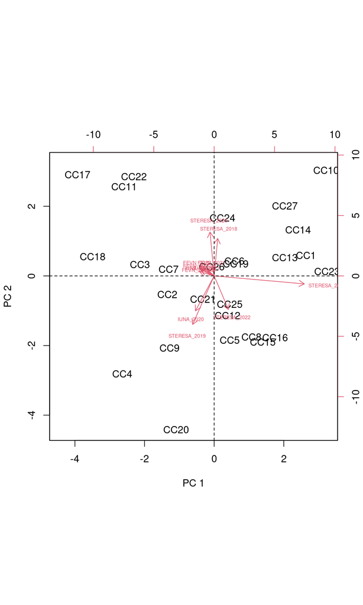

```r
# eighvectors
PC <- 2
Sg2 <- Sg[,1:PC]
Se2 <- Se[,1:PC]
GE2 <- Sg2 %*% t(Se2)

# Ploting
biplot(Sg[,1:2], Se[,1:2],  xlab = "PC 1", ylab = "PC 2",cex=c(1,0.5))
abline(h = 0, lty = 2);abline(v = 0, lty = 2)
```

**Some conclusions:**

- Genotypes and environments positioned close to the origin of the axes do not interact with each other
- Genotypes and environments lying far away from the origin of axes show very big interaction and, therefore, high yield instability.
- Here, we can see some similar and contrasting results from the FW regression – that is perfectly fine, since both methods relies on different assumptions to describe the GE. For example:
  - Genotype `CC26` was positioned in the center of the biplot representing not relevant interaction, and therefore good general performance. This genotype was not pointed out in the FW regression.
  - Genotype `CC20` `CC10` showed high sensitivity in the FW and AMMI plot analyses. Here, we can quantify it by defining a group of environments guiding this results.

## Metan package

There are several packages that can be used to perform and plot AMMI plot. In the past section, we presented the [statgenGxE](https://cran.r-project.org/web/packages/statgenGxE/vignettes/statgenGxE.html) package to carry out the FW regression. While this software can also handle AMMI analyses, we will consider this opportunity to present a second package, called [metan](https://tiagoolivoto.github.io/metan/index.html).

We already discussed that AMMI analyses relies on a linear model, that combine ANOVA and SVD decomposition. metan will implement this same model, but will present some alternatives to better visualize the results. Here in, we will implement the analyses in two examples: post-harvest in blueberry and the traditional coffee data.

### Blueberry post-harvest analyses

We will use a real example in blueberry to illustrate the use of biplots for GxE analyses. The real data was described by [Sater et al., (2019)](https://www.sciencedirect.com/science/article/pii/S0304423821005756?dgcid=author), where we described the storage factors affecting sensory, physical and chemical attributes of six blueberry cultivars.

Some notes about this data set:

- Genotype: six blueberry cultivars (Keecrisp, Indigocrisp, Patricia, Endura, Emerald and Arcadia)
- Environment: three different storage factors (after 1 day, 8 days and 15 days in the cold condiction)
- Repetition: herein, we used two harvests during the season as our repetition
- Response variable: deflection (firmness of the berries)
- **Central question: what genotype is more sensible (in terms of firmness variation) to post-harvest conditions in blueberry?**

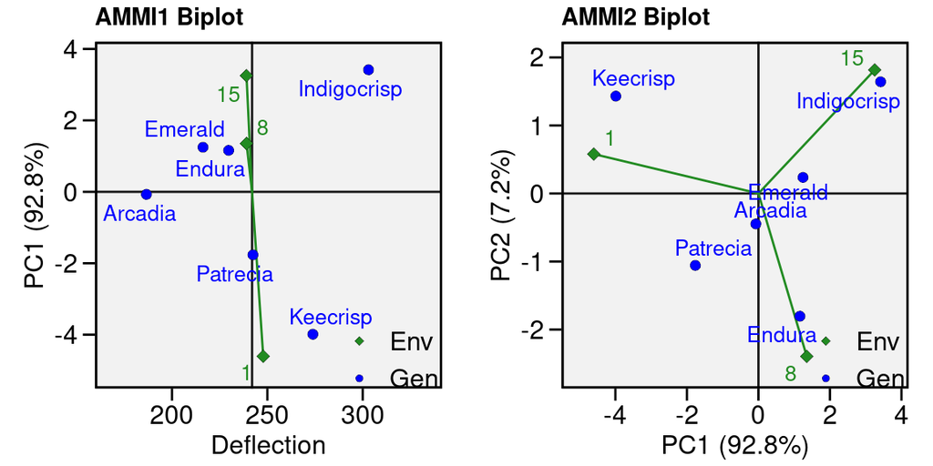

```r
library(metan)
library(dplyr)
library(openxlsx)
library(gridExtra)

# Download the data
setwd("/home/felipe/UFL Dropbox/Luis Ferrao/classes/QuantGen_24/Class11_GxE/Class_metan")
firmness = read.xlsx("./Summery Blueberry Instrmental Frimness 2015 2016.xlsx")

data = firmness %>%
  group_by(Cultivar,Harvest, Storage) %>%
  summarize_if(is.numeric, mean, na.rm=T) %>%
  select(Cultivar,Storage,Harvest,Deflection) %>%
  droplevels() %>%
  as.data.frame()

# Fitting models in metan
data$Cultivar = as.factor(data$Cultivar)
data$Storage = as.factor(data$Storage)
data$Harvest=as.factor(data$Harvest)
AMMI_model <- performs_ammi(data,
                            env = Storage,
                            gen = Cultivar,
                            rep=Harvest,
                            resp = Deflection,
                            verbose = F)
a1=plot_scores(AMMI_model)
a2=plot_scores(AMMI_model,type=2)
a3 = plot_scores(AMMI_model,type=4)
grid.arrange(a1,a2,ncol=2)
```

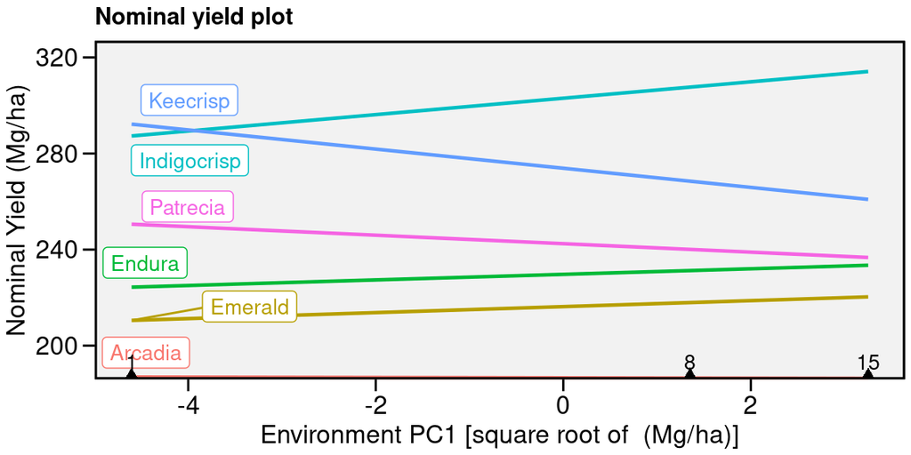

```r
a3
```

**Interpretation**

- X-axis in the `a1` plot corresponds to the deviation from the mean of a genotype and an environment
- Y-axis in the `a1` is the PCA
- Genotypes with a higher mean are plotted toward the righ-hand in the `a1` plot. We can see, for example, how `Indigocrisp` is a good genotype after 15 days, while `Keecrisp` has a good response at one day.
- We can confirm the results looking at the nomimal plot in the `a3`.
- `a1` and `a2` plots can confirm that `Arcadia` is a stable genotype across all the environments, but with low phenotypic performance.

**Other plots**

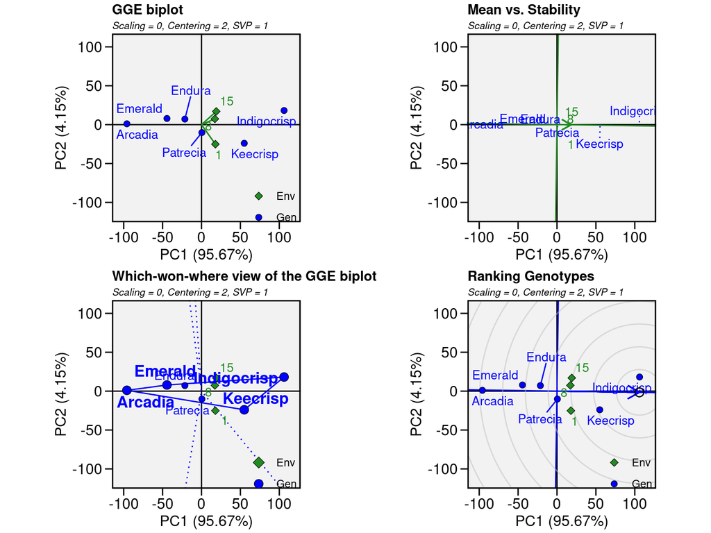

```r
library(metan)
library(gridExtra)
gge_model <- gge(data, Storage, Cultivar, Deflection,svp="genotype")
a= plot(gge_model)
b= plot(gge_model, type = 2)
c= plot(gge_model, type = 3)
d= plot(gge_model, type = 8)
grid.arrange(a,b,c,d,ncol=2)
```

**Interpretation**

Great advance on using the GGE method is the interpretation. We can create nice plots and see some important trend in the data.

- `type=1`: classical biplot
- `type 2`: Mean performance vs. stability. Herein, we draw an average environment coordinate (AEC) on the genotype-focused biplot (represented as a green line). The line that passes through the biplot origin and the AEC may be called the average. The projections of genotype markers onto this axis should, therefore, approximate the mean of the genotypes. Thus, `Indigocrisp` was clearly the best genotype, on average, while `Arcadia` showed the best stability, however a poor phenotypic performance.
- `type 3`: Which-won-where. A polygon is drawn joining the genotypes located farthest from the origin. The vertex genotypes are, therefore, among the most responsive genotypes in different environments. A genotype located at the origin would rank the same in all environments and is not at all responsive to the environments.
- `type 8`: Ranking genotypes. Compares all genotypes with the “ideal” genotype. The ideal genotype, represented by the small circle with an arrow pointing to it, is defined as having the highest phenotypic performance in all environments. Therefore, it combines stability and performance. In out example, `Indigocrisp` showed the best general performance.

### Coffee data set

We will return to the classical coffee example, but using the metan package.

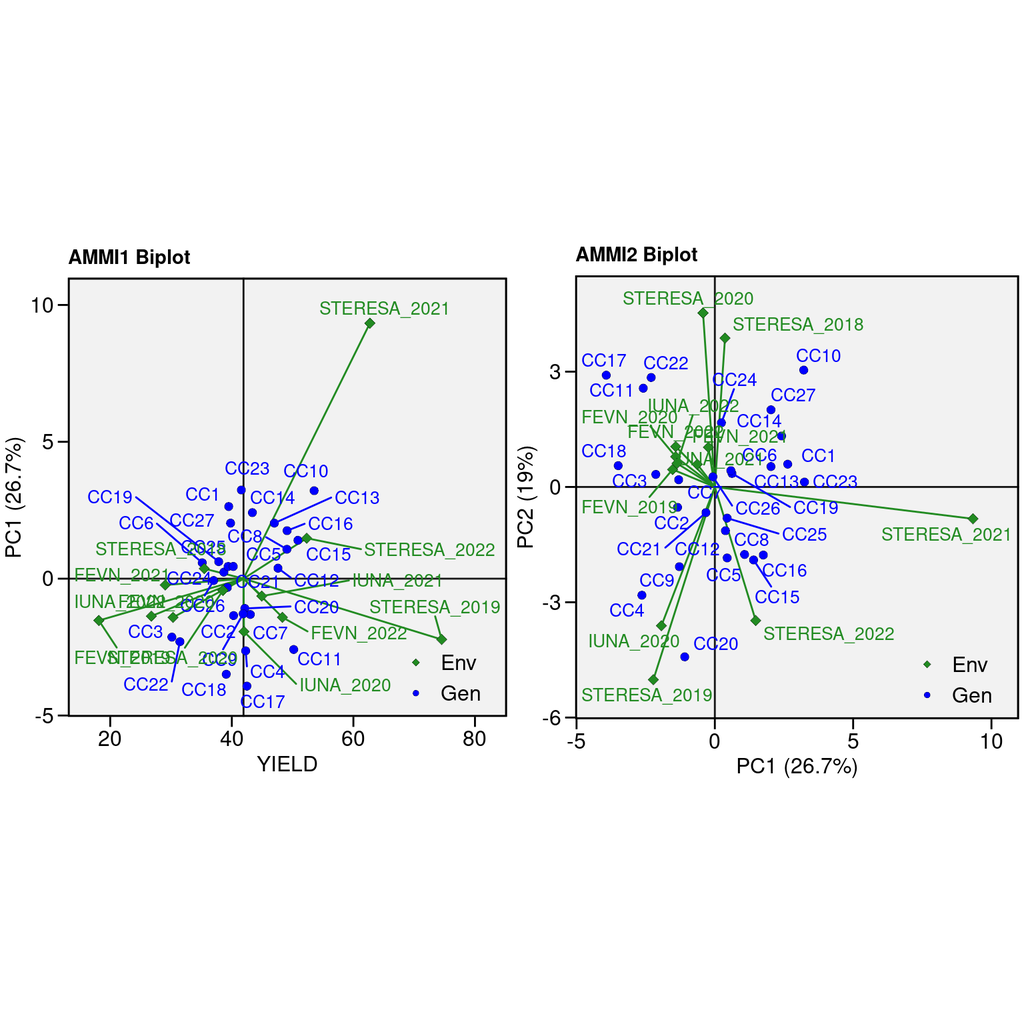

```r
library(metan)
library(gridExtra)

# Coffee data set
df = read.xlsx("/home/felipe/UFL Dropbox/Luis Ferrao/classes/QuantGen_24/Class11_GxE/coffee_27ind_canephora_12env.xlsx")
df$id = as.factor(df$id)
df$ENV = as.factor(df$ENV)
df$BLOCK = as.factor(df$BLOCK)

# metan package
AMMI_model <- performs_ammi(df,
                            env = ENV,
                            gen = id,
                            rep=BLOCK,
                            resp = YIELD,
                            verbose = F)
a1=plot_scores(AMMI_model)
a2=plot_scores(AMMI_model,type=2)
grid.arrange(a1,a2,ncol=2)
```

**Some comments**

- As we already reported, results from AMMI and FW regressions are not the same ! This is expected, since both methods are fitting different models, with distinction assumptions.
- When comparing coffee and blueberry data set, principal components are explaining different portions of the phenotypic variance. In coffee, PC1 is lower than the same PC reported in the blueberry example. It indicates the complexity of the coffee data set, and the importance to look the interaction in two different dimensions.

# Conclusion

GxE interaction is a dynamic topic in plant breeding, where multiple methods and approaches have been proposed in the literature. The use of mixed models as presented along the course is maybe one of the most powerful and modern way to describe GxE and ranking genotypes. However, we have a group of more parsimonious models that have their (i) historical importance and (ii) straightforward implementation and visualization.

Herein, we focused on the interpretation of biplot graphics. My personal opinion: I like this kind of analyses ! Not only because it is easy to be implemented, but also leverage the interpretation. We can present this plots to any breeders, growers and/or statisticians; everyone will speak the same language.

# References

- Yan, Weikai., and Manjit S. Kang. 2003. GGE biplot analysis : a graphical tool for breeders, geneticists, and agronomists. CRC Press.
- Yan, W., M. S. Kang, B. Ma, S. Woods, and P. L. Cornelius. 2007. “GGE Biplot vs. AMMI Analysis of Genotype-by-Environment Data.” Crop Science 47 (2): 641–53.
- Olivoto, T., and Lúcio, A.D. (2020). metan: an R package for multi-environment trial analysis. Methods Ecol Evol. 11:783-789 doi:10.1111/2041-210X.13384
- Onofri and Ciriciofolo, 2007. Using R to Perform the AMMI Analysis on Agriculture Variety Trials. [Link](https://journal.r-project.org/articles/RN-2007-003/RN-2007-003.pdf)